# bikesharing

Maciej

2023-08-17

## Scenario

You are a junior data analyst working in the marketing analyst team at Cyclistic, a bike-share company in Chicago. The director of marketing believes the company’s future success depends on maximizing the number of annual memberships. Therefore, your team wants to understand how casual riders and annual members use Cyclistic bikes differently. From these insights, your team will design a new marketing strategy to convert casual riders into annual members. But first, Cyclistic executives must approve your recommendations, so they must be backed up with compelling data insights and professional data visualizations.

### Three questions will guide the future marketing program:

1. How do annual members and casual riders use Cyclistic bikes differently?
2. Why would casual riders buy Cyclistic annual memberships?
3. How can Cyclistic use digital media to influence casual riders to become members?

# Bike-share project

The objectives of this project is:

- Grab data from given source : [Link for files](https://divvy-tripdata.s3.amazonaws.com/index.html)
- Consolidate/aggregate data of bike trips from bike-sharing company
- Make analysis due to business task.
- Share insights and recommendations

## Installing required packages

```r
library(tidyverse)
```

```r
library(lubridate)
library(ggplot2)
library(dplyr)
library(here)
library(aws.s3)
```

## Setting global language

```r
Sys.setlocale("LC_TIME", "C")
```

```
## [1] "C"
```

## Setting enviroment for aws s3

```r
Sys.setenv("AWS_DEFAULT_REGION" = "eu-north-1")
```

## Checking connection to bucket

```r
bucket_exists(
  bucket = "s3://analitycal-projects-data/",
  region = "eu-north-1"
)
```

[output not shown]

## Listing bucket contents and saving file names

```r
bucket_objects <- get_bucket("analitycal-projects-data")
first_12_objects <- head(bucket_objects,12)
names_of_s3_files <- sapply(first_12_objects, function(obj) obj$Key)
```

## Downloading csv files from bucket

There is 12 CSV files to download in cyclist_data/csv_files folder. Downloaded files are stored at project directory

```r
subfolder = "cyclist_data/csv_files/"
files_date <- c("2022_08", "2022_09", "2022_10", "2022_11", "2022_12", "2023_01", "2023_02", "2023_03", "2023_04", "2023_05", "2023_06", "2023_07")
file_ending = "_trip_data.csv"



for (name_of_s3_file in names_of_s3_files) {

  save_object(
    object = name_of_s3_file,
    bucket = "s3://analitycal-projects-data/",
    region = "eu-north-1",
    file = name_of_s3_file
  )

}
```

## Setting relative path to csv files

```r
main_path <- here("cyclist_data", "csv_files")
print(main_path)
```

```
## [1] "C:/Users/krzyw/OneDrive/Dokumenty/r-projects/bike-share-v1/cyclist_data/csv_files"
```

## Reading CSV files and saving to list

Reading already downloaded files that are stored at cyclist_data/csv_files

```r
list_of_month_trips <- list()
i <- 1

for (name_of_s3_file in names_of_s3_files) {
  file_path <- name_of_s3_file
  data <- read.csv(file_path)
  list_of_month_trips[[i]] <- data
  i <- i + 1
}
```

## Dropping irrelevant columns

Columns associated with place of trips are irrelevant because business tasks are related to when and how questions but not where. For example information about the most frequent start/end station will not help to find patterns that can help to find a way to attract customers to buy a membership. Eventually it can be useful for placing advertisments in these places.

```r
relevant_columns <- c("ride_id","started_at","ended_at","member_casual")
list_length = length(list_of_month_trips)
for(i in 1:list_length)
{
  list_of_month_trips[[i]] <- subset(list_of_month_trips[[i]],select=relevant_columns)

}
```

## Consolidating the 12 datasets into big one df

```r
all_trips <- bind_rows(list_of_month_trips)
```

## Summary

```r
summary(all_trips)
```

```
##    ride_id           started_at          ended_at         member_casual
##  Length:5115139     Length:5115139     Length:5115139     Length:5115139
##  Class :character   Class :character   Class :character   Class :character
##  Mode  :character   Mode  :character   Mode  :character   Mode  :character
```

```r
head(all_trips)
```

```
##            ride_id          started_at            ended_at member_casual
## 1 550CF7EFEAE0C618 2022-08-07 21:34:15 2022-08-07 21:41:46        casual
## 2 DAD198F405F9C5F5 2022-08-08 14:39:21 2022-08-08 14:53:23        casual
## 3 E6F2BC47B65CB7FD 2022-08-08 15:29:50 2022-08-08 15:40:34        casual
## 4 F597830181C2E13C 2022-08-08 02:43:50 2022-08-08 02:58:53        casual
## 5 0CE689BB4E313E8D 2022-08-07 20:24:06 2022-08-07 20:29:58        casual
## 6 BFA7E7CC69860C20 2022-08-08 13:06:08 2022-08-08 13:19:09        casual
```

## Adding date columns

```r
all_trips$date <- as.Date(all_trips$started_at) #The default format is yyyy-mm-dd
all_trips$month <- format(as.Date(all_trips$date), "%m")
all_trips$day <- format(as.Date(all_trips$date), "%d")
all_trips$year <- format(as.Date(all_trips$date), "%Y")
all_trips$day_of_week <- format(as.Date(all_trips$date), "%A")
```

## Changing column types

Making changes to column type started_at and ended_at from char to posixct due to latter computation - ride_length

```r
all_trips$started_at <-as.POSIXct(all_trips$started_at,
                                             format = "%Y-%m-%d %H:%M:%S")
all_trips$ended_at <-as.POSIXct(all_trips$ended_at,
                                             format = "%Y-%m-%d %H:%M:%S")
```

## Adding ride_length column

Adding ride_length column that compute the difference in seconds between start and end of the trip

```r
all_trips$ride_length <- as.numeric(all_trips$ended_at - all_trips$started_at)
```

## Filtering and making new subset of records

Deleting rows that have ride length less than 0 - these rows are irrelevant from analysis point of view and rows that have empty string in member_casual

```r
all_trips_v2 <- all_trips %>%
  filter(ride_length > 0, member_casual %in% c("member", "casual"))
```

## Comparing members and casual riders

Aggregating groups the unique values in member_casual column and compute given statistical value for each group

```r
aggregate(all_trips_v2$ride_length ~ all_trips_v2$member_casual, FUN = mean)
```

```
##   all_trips_v2$member_casual all_trips_v2$ride_length
## 1                     casual                1560.7605
## 2                     member                 731.4244
```

```r
aggregate(all_trips_v2$ride_length ~ all_trips_v2$member_casual, FUN = median)
```

```
##   all_trips_v2$member_casual all_trips_v2$ride_length
## 1                     casual                      710
## 2                     member                      507
```

```r
aggregate(all_trips_v2$ride_length ~ all_trips_v2$member_casual, FUN = max)
```

```
##   all_trips_v2$member_casual all_trips_v2$ride_length
## 1                     casual                  2486835
## 2                     member                    93597
```

```r
aggregate(all_trips_v2$ride_length ~ all_trips_v2$member_casual, FUN = min)
```

```
##   all_trips_v2$member_casual all_trips_v2$ride_length
## 1                     casual                        1
## 2                     member                        1
```

```r
aggregate(all_trips_v2$ride_length ~ all_trips_v2$member_casual, FUN = summary)
```

```
##   all_trips_v2$member_casual all_trips_v2$ride_length.Min.
## 1                     casual                        1.0000
## 2                     member                        1.0000
##   all_trips_v2$ride_length.1st Qu. all_trips_v2$ride_length.Median
## 1                         400.0000                        710.0000
## 2                         294.0000                        507.0000
##   all_trips_v2$ride_length.Mean all_trips_v2$ride_length.3rd Qu.
## 1                     1560.7605                        1323.0000
## 2                      731.4244                         872.0000
##   all_trips_v2$ride_length.Max.
## 1                  2486835.0000
## 2                    93597.0000
```

## Defining the order of caterogical values

Making order of day_of_week column and their values without changing the factual order of records

```r
all_trips_v2$day_of_week <- ordered(all_trips_v2$day_of_week, levels=c("Sunday", "Monday", "Tuesday", "Wednesday", "Thursday", "Friday", "Saturday"))
```

## Aggregating the average ride time

Aggregating by each day and each member type in ordered manner

```r
aggregate(all_trips_v2$ride_length ~ all_trips_v2$member_casual + all_trips_v2$day_of_week, FUN = mean)
```

```
##    all_trips_v2$member_casual all_trips_v2$day_of_week all_trips_v2$ride_length
## 1                      casual                   Sunday                1850.8723
## 2                      member                   Sunday                 809.5448
## 3                      casual                   Monday                1478.7873
## 4                      member                   Monday                 699.9498
## 5                      casual                  Tuesday                1388.5087
## 6                      member                  Tuesday                 702.2417
## 7                      casual                Wednesday                1309.2345
## 8                      member                Wednesday                 696.8366
## 9                      casual                 Thursday                1338.6006
## 10                     member                 Thursday                 703.2275
## 11                     casual                   Friday                1530.0299
## 12                     member                   Friday                 727.6204
## 13                     casual                 Saturday                1813.5846
## 14                     member                 Saturday                 818.6968
```

## Plot 1

Comparing the number of rides by each type of membership

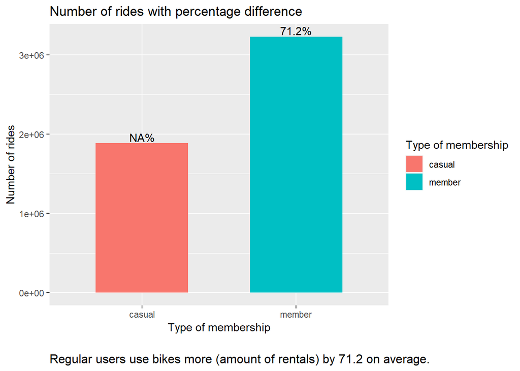

```r
data <- all_trips_v2 %>%
  group_by(member_casual) %>%
  summarise(number_of_rides = n()) %>%
  ungroup() %>%
  mutate(percent_change = ((number_of_rides - lag(number_of_rides)) / lag(number_of_rides)) * 100)

p <- ggplot(data, aes(x = member_casual, y = number_of_rides, fill = member_casual)) +
  geom_col(width=0.6) +
  geom_text(aes(label = paste0(round(percent_change, 1), "%")),
      vjust = -0.2) +
  labs(title = "Number of rides with percentage difference",
       y = "Number of rides",
       x = "Type of membership",
       caption ="Regular users use bikes more (amount of rentals) by 71.2 on average.",
       fill="Type of membership") +
  theme(plot.caption = element_text(margin=margin(t=20), size=12,hjust=0))

print(p)
```